# SCRAPING IMDB SITE

## Piecing everything together

Now let’s piece together everything we’ve done so far! In the following code cell, we start by:

Loop through the years_url list to vary the release_date parameter of the URL. For each element in years_url, loop through the pages list to vary the page parameter of the URL. Make the GET requests within the pages loop (and give the headers parameter the right value to make sure we get only English content). Pause the loop for a time interval between 8 and 15 seconds. Monitor each request as discussed before. Throw a warning for non-200 status codes. Break the loop if the number of requests is greater than expected. Convert the response‘s HTML content to a BeautifulSoup object. Extract all movie containers from this BeautifulSoup object. Loop through all these containers. Extract the data if a container has a Metascore.

```python
headers = {"Accept-Language": "en-US, en;q=0.5"}
# Redeclaring the lists to store data in
names = []
years = []
imdb_ratings = []
metascores = []
votes = []

# Preparing the monitoring of the loop
start_time = time()
requests = 0

# For every year in the interval 2000-2017
for year_url in years_url:

    # For every page in the interval 1-4
    for page in pages:

        # Make a get request
        response = get('https://www.imdb.com/search/title?release_date=' + year_url +
        '&sort=num_votes,desc&page=' + page, headers = headers)

        # Pause the loop
        sleep(randint(8,15))

        # Monitor the requests
        requests += 1
        elapsed_time = time() - start_time
        print('Request:{}; Frequency: {} requests/s'.format(requests, requests/elapsed_time))
        clear_output(wait = True)

        # Throw a warning for non-200 status codes
        if response.status_code != 200:
            warn('Request: {}; Status code: {}'.format(requests, response.status_code))

        # Break the loop if the number of requests is greater than expected
        if requests > 72:
            warn('Number of requests was greater than expected.')
            break

        # Parse the content of the request with BeautifulSoup
        page_html = BeautifulSoup(response.text, 'html.parser')

        # Select all the 50 movie containers from a single page
        mv_containers = page_html.find_all('div', class_ = 'lister-item mode-advanced')

        # For every movie of these 50
        for container in mv_containers:
            # If the movie has a Metascore, then:
            if container.find('div', class_ = 'ratings-metascore') is not None:

                # Scrape the name
                name = container.h3.a.text
                names.append(name)

                # Scrape the year
                year = container.h3.find('span', class_ = 'lister-item-year').text
                years.append(year)

                # Scrape the IMDB rating
                imdb = float(container.strong.text)
                imdb_ratings.append(imdb)

                # Scrape the Metascore
                m_score = container.find('span', class_ = 'metascore').text
                metascores.append(int(m_score))

                # Scrape the number of votes
                vote = container.find('span', attrs = {'name':'nv'})['data-value']
                votes.append(int(vote))
```

```
Request:68; Frequency: 0.062231746355703436 requests/s
```

```python
movie_ratings = pd.DataFrame({'movie': names,
'year': years,
'imdb': imdb_ratings,
'metascore': metascores,
'votes': votes
})
print(movie_ratings.info())
movie_ratings.head(10)
```

```
<class 'pandas.core.frame.DataFrame'>
RangeIndex: 3092 entries, 0 to 3091
Data columns (total 5 columns):
 #   Column     Non-Null Count  Dtype
---  ------     --------------  -----
 0   movie      3092 non-null   object
 1   year       3092 non-null   object
 2   imdb       3092 non-null   float64
 3   metascore  3092 non-null   int64
 4   votes      3092 non-null   int64
dtypes: float64(1), int64(2), object(2)
memory usage: 120.9+ KB
None
```

|  | movie | year | imdb | metascore | votes |
| --- | --- | --- | --- | --- | --- |
| 0 | Gladiator | (2000) | 8.5 | 67 | 1364178 |
| 1 | Memento | (2000) | 8.4 | 80 | 1143328 |
| 2 | Snatch | (2000) | 8.3 | 55 | 793442 |
| 3 | Requiem for a Dream | (2000) | 8.3 | 68 | 779089 |
| 4 | X-Men | (2000) | 7.4 | 64 | 577754 |
| 5 | Cast Away | (2000) | 7.8 | 73 | 535579 |
| 6 | American Psycho | (2000) | 7.6 | 64 | 505551 |
| 7 | Unbreakable | (2000) | 7.3 | 62 | 392066 |
| 8 | Mission: Impossible II | (2000) | 6.1 | 59 | 318886 |
| 9 | Meet the Parents | (2000) | 7.0 | 73 | 314528 |

## Cleaning the scraped data

We’ll clean the scraped data with two goals in mind: plotting the distribution of IMDB and Metascore ratings, and sharing the dataset. Consequently, our data cleaning will consist of:

Reordering the columns. Cleaning the year column and convert the values to integers. Checking the extreme rating values to determine if all the ratings are within the expected intervals. Normalizing one of the ratings type (or both) for generating a comparative histogram. Let’s start by reordering the columns:

```python
movie_ratings = movie_ratings[['movie', 'year', 'imdb', 'metascore', 'votes']]
movie_ratings.head()
```

|  | movie | year | imdb | metascore | votes |
| --- | --- | --- | --- | --- | --- |
| 0 | Gladiator | (2000) | 8.5 | 67 | 1364178 |
| 1 | Memento | (2000) | 8.4 | 80 | 1143328 |
| 2 | Snatch | (2000) | 8.3 | 55 | 793442 |
| 3 | Requiem for a Dream | (2000) | 8.3 | 68 | 779089 |
| 4 | X-Men | (2000) | 7.4 | 64 | 577754 |

Now let’s convert all the values in the year column to integers.

Right now all the values are of the object type. To avoid ValueErrors upon conversion, we want the values to be composed only from numbers from 0 to 9.

Let’s examine the unique values of the year column. This helps us to get an idea of what we could do to make the conversions we want. To see all the unique values, we’ll use the unique() method:

```python
movie_ratings['year'].unique()
```

```
array(['(2000)', '(I) (2000)', '(2001)', '(2002)', '(2003)', '(2004)',
       '(I) (2004)', '(2005)', '(I) (2005)', '(2006)', '(I) (2006)',
       '(2007)', '(I) (2007)', '(2008)', '(I) (2008)', '(2009)',
       '(I) (2009)', '(2010)', '(I) (2010)', '(2011)', '(I) (2011)',
       '(2012)', '(I) (2012)', '(2013)', '(I) (2013)', '(2014)',
       '(I) (2014)', '(II) (2014)', '(2015)', '(I) (2015)', '(II) (2015)',
       '(2016)', '(II) (2016)', '(IX) (2016)', '(I) (2016)'], dtype=object)
```

Counting from the end toward beginning, we can see that the years are always located from the fifth character to the second. We’ll use the .str() method to select only that interval. We’ll also convert the result to an integer using the astype() method:

```python
movie_ratings.loc[:, 'year'] = movie_ratings['year'].str[-5:-1].astype(int)
```

```python
movie_ratings['year'].head(3)
```

```
0    2000
1    2000
2    2000
Name: year, dtype: int32
```

Now we’ll check the minimum and maximum values of each type of rating. We can do this very quickly by using pandas’ describe() method. When applied on a DataFrame, this method returns various descriptive statistics for each numerical column of the DataFrame. In the next line of code we select only those rows that describe the minimum and maximum values, and only those columns which describe IMDB ratings and Metascores.

```python
movie_ratings.describe().loc[['min', 'max'], ['imdb', 'metascore']]
```

|  | imdb | metascore |
| --- | --- | --- |
| min | 4.1 | 24.0 |
| max | 9.0 | 100.0 |

There are no unexpected outliers.

From the values above, you can see that the two ratings have different scales. To be able to plot the two distributions on a single graph, we’ll have to bring them to the same scale. Let’s normalize the imdb column to a 100-points scale.

We’ll multiply each IMDB rating by 10, and then we’ll do a quick check by looking at the first 3 rows:

```python
movie_ratings['n_imdb'] = movie_ratings['imdb'] * 10
movie_ratings.head(3)
```

|  | movie | year | imdb | metascore | votes | n_imdb |
| --- | --- | --- | --- | --- | --- | --- |
| 0 | Gladiator | 2000 | 8.5 | 67 | 1364178 | 85.0 |
| 1 | Memento | 2000 | 8.4 | 80 | 1143328 | 84.0 |
| 2 | Snatch | 2000 | 8.3 | 55 | 793442 | 83.0 |

```python
##Saving to CSV
movie_ratings.to_csv('movie_ratings.csv')
```

As a side note, I strongly recommend saving the scraped dataset before exiting (or restarting) your notebook kernel. This way you will only have to import the dataset when you resume working, and don’t have to run the scraping script again. This becomes extremely useful if you scrape hundreds or thousands of web pages.

Finally, let’s plot the distributions!

### Plotting and analyzing the distributions

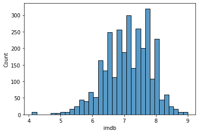

```python
import matplotlib.pyplot as plt
'''
fig, axes = plt.subplots(nrows = 1, ncols = 3, figsize = (16,4))
ax1, ax2, ax3 = fig.axes
ax1.hist(movie_ratings['imdb'], bins = 10, range = (0,10)) # bin range = 1
ax1.set_title('IMDB rating')
ax2.hist(movie_ratings['metascore'], bins = 10, range = (0,100)) # bin range = 10
ax2.set_title('Metascore')
ax3.hist(movie_ratings['n_imdb'], bins = 10, range = (0,100), histtype = 'step')
ax3.hist(movie_ratings['metascore'], bins = 10, range = (0,100), histtype = 'step')
ax3.legend(loc = 'upper left')
ax3.set_title('The Two Normalized Distributions')
for ax in fig.axes:
    ax.spines['top'].set_visible(False)
    ax.spines['right'].set_visible(False)
plt.show()
'''
import seaborn as sns
sns.histplot(data=movie_ratings, x="imdb")
```

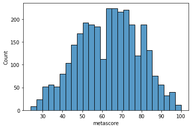

```python
sns.histplot(data=movie_ratings, x="metascore")
```

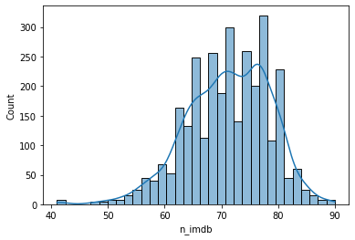

```python
sns.histplot(data=movie_ratings, x="n_imdb", kde=True)
```

Starting with the IMDB histogram, we can see that most ratings are between 6 and 8. There are few movies with a rating greater than 8, and even fewer with a rating smaller than 4. This indicates that both very good movies and very bad movies are rarer.

What might be the reason for that skew in the IMDB distribution? One hypothesis is that many users tend to have a binary method of assessing movies. If they like the movie, they give it a 10. If they don’t like the movie, they give it a very small rating, or they don’t bother to rate the movie. This an interesting problem that’s worth being explored in more detail.